# Analysis of the Impact of the Transmission Type on Miles Per Gallon

joergandi

17 August 2015

## Overview

The following analysis of the impact of the transmission type on miles per gallon is based on the R built-in dataset mtcars, extracted from the 1974 Motor Trend US magazine. The objective is to determine if an automatic or manual transmission is better for MPG and to quantify that difference.

## Executive Summary

Although the data indicates that using a manual instead of an automatic transmission would increase MPG by approximately 7.2, this statement only holds if all other parameters which influence MPG are ignored. In fact, fuel consumption can be explained to a large extent by weight and horsepower alone. If one would like to buy a 1973/74 car model with an expected decent consumption, one should rather focus on car weight and horsepower than on the transmission type.

## Exploratory data analysis

Transmission type seems to have an impact on MPG if no other variables are considered, **cf. appendix figure 1**; however, other variables seem to impact MPG as well, **cf. appendix figure 2**.

## Quantification of transmission type impact on mpg

The plots suggests that using a manual transmission increases MPG significantly, which is confirmed by the small p-value of a t-test, allowing to reject the hypothesis of no impact.

```r
data(mtcars)
t.test(mpg~am,data=mtcars,conf.level=0.95)$p.value
```

```
## [1] 0.001373638
```

We fit a linear model to the factor variable of transmission type and mpg.

```r
fit<-lm(mpg~factor(am),data=mtcars)
summary(fit)$coefficients
```

```
##              Estimate Std. Error   t value     Pr(>|t|)
## (Intercept) 17.147368   1.124603 15.247492 1.133983e-15
## factor(am)1  7.244939   1.764422  4.106127 2.850207e-04
```

## Which transmission is better for MPG?

```r
fit2<-lm(mpg~wt*hp ,data=mtcars)
fit3<-update(fit2,mpg~wt*hp +factor(am))
anova(fit2,fit3)
```

```
## Analysis of Variance Table
##
## Model 1: mpg ~ wt * hp
## Model 2: mpg ~ wt + hp + factor(am) + wt:hp
##   Res.Df    RSS Df Sum of Sq      F Pr(>F)
## 1     28 129.76
## 2     27 129.72  1  0.042292 0.0088 0.9259
```

## Conclusion

Without considering the influence of other variables, using a manual instead of an automatic transmission increases mpg on average by 7.2449393. However, the variance in mpg in this dataset can be explained to a large extent by weight and horsepower and the transmission type seems to have a small impact when considering the impact of other variables.

## Appendix

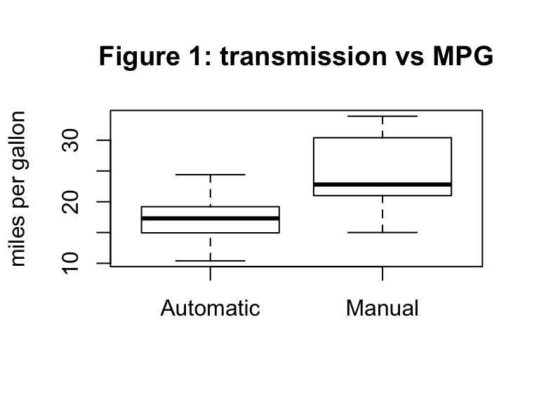

```r
boxplot(mpg~factor(am),data=mtcars, #xlab="transmission type",
        names = c("Automatic", "Manual"),
       ylab="miles per gallon", main="Figure 1: transmission vs MPG")
```

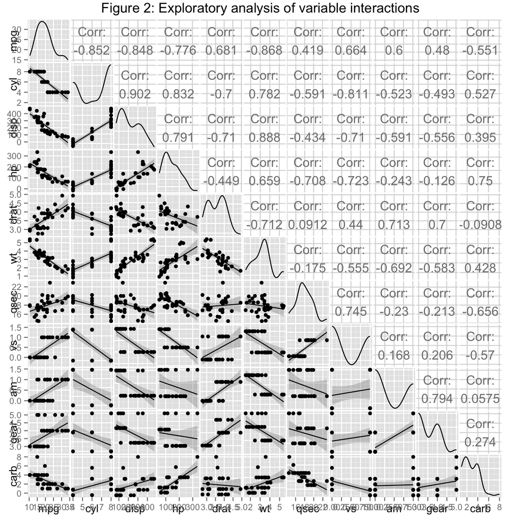

```r
require(GGally)
require(ggplot2)
g=ggpairs(mtcars,lower=list(continuous="smooth"),params=c(method="loess"),
          title="Figure 2: Exploratory analysis of variable interactions")
g
```

```r
#Figure 3: Comparing different linear models using analysis of variance
#  with an increasing number of variables
m0<-lm(mpg~wt+hp,data=mtcars)
m1<-update(m0,mpg~wt+hp+factor(cyl))
m2<-update(m0,mpg~wt+hp+factor(am))
m3<-update(m0,mpg~wt+hp+factor(cyl)+factor(am))
m4<-lm(mpg~wt*hp,data=mtcars)
anova(m0,m1,m2,m3)
```

```
## Analysis of Variance Table
##
## Model 1: mpg ~ wt + hp
## Model 2: mpg ~ wt + hp + factor(cyl)
## Model 3: mpg ~ wt + hp + factor(am)
## Model 4: mpg ~ wt + hp + factor(cyl) + factor(am)
##   Res.Df    RSS Df Sum of Sq      F  Pr(>F)
## 1     29 195.05
## 2     27 160.78  2    34.270 2.9499 0.07005 .
## 3     28 180.29 -1   -19.513 3.3594 0.07830 .
## 4     26 151.03  2    29.265 2.5191 0.10000 .
## ---
## Signif. codes:  0 '***' 0.001 '**' 0.01 '*' 0.05 '.' 0.1 ' ' 1
```

```r
summary(m3)
```

```
##
## Call:
## lm(formula = mpg ~ wt + hp + factor(cyl) + factor(am), data = mtcars)
##
## Residuals:
##     Min      1Q  Median      3Q     Max
## -3.9387 -1.2560 -0.4013  1.1253  5.0513
##
## Coefficients:
##              Estimate Std. Error t value Pr(>|t|)
## (Intercept)  33.70832    2.60489  12.940 7.73e-13 ***
## wt           -2.49683    0.88559  -2.819  0.00908 **
## hp           -0.03211    0.01369  -2.345  0.02693 *
## factor(cyl)6 -3.03134    1.40728  -2.154  0.04068 *
## factor(cyl)8 -2.16368    2.28425  -0.947  0.35225
## factor(am)1   1.80921    1.39630   1.296  0.20646
## ---
## Signif. codes:  0 '***' 0.001 '**' 0.01 '*' 0.05 '.' 0.1 ' ' 1
##
## Residual standard error: 2.41 on 26 degrees of freedom
## Multiple R-squared:  0.8659, Adjusted R-squared:  0.8401
## F-statistic: 33.57 on 5 and 26 DF,  p-value: 1.506e-10
```

```r
summary(m4)
```

```
##
## Call:
## lm(formula = mpg ~ wt * hp, data = mtcars)
##
## Residuals:
##     Min      1Q  Median      3Q     Max
## -3.0632 -1.6491 -0.7362  1.4211  4.5513
##
## Coefficients:
##             Estimate Std. Error t value Pr(>|t|)
## (Intercept) 49.80842    3.60516  13.816 5.01e-14 ***
## wt          -8.21662    1.26971  -6.471 5.20e-07 ***
## hp          -0.12010    0.02470  -4.863 4.04e-05 ***
## wt:hp        0.02785    0.00742   3.753 0.000811 ***
## ---
## Signif. codes:  0 '***' 0.001 '**' 0.01 '*' 0.05 '.' 0.1 ' ' 1
##
## Residual standard error: 2.153 on 28 degrees of freedom
## Multiple R-squared:  0.8848, Adjusted R-squared:  0.8724
## F-statistic: 71.66 on 3 and 28 DF,  p-value: 2.981e-13
```

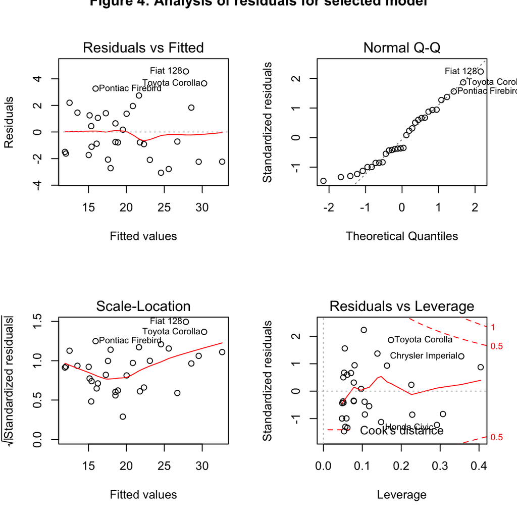

```r
par(mfrow=c(2,2))
plot(m4)

title("Figure 4: Analysis of residuals for selected model", outer=TRUE)
```